# Untitled

Martin S. Bjørnerem

7 desember 2018

# Vårt prosjekt:

## Korrelasjonsanalyse

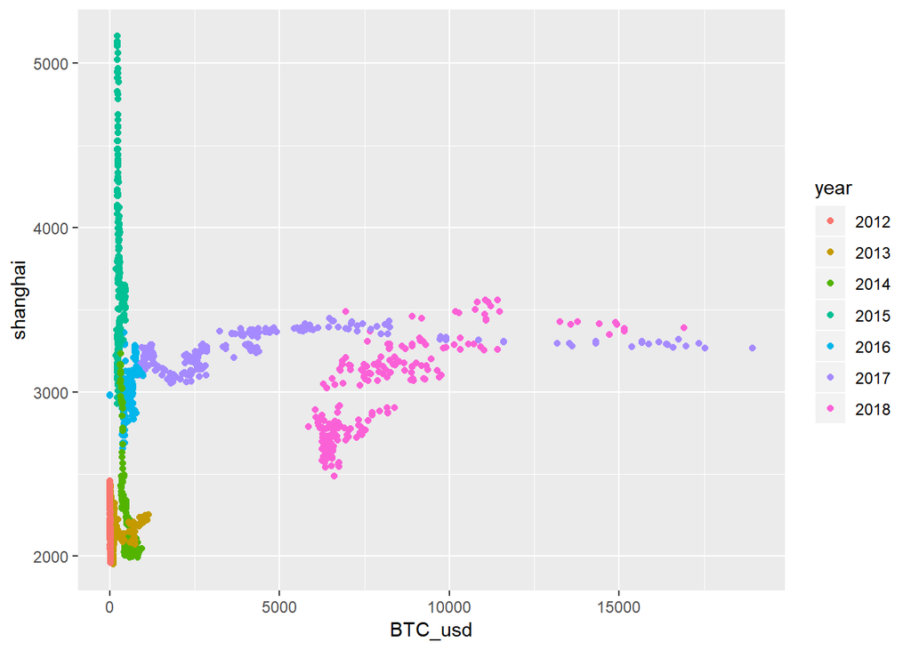

```
## # A tibble: 1,643 x 3
##    Dato       shanghai BTC_usd
##    <date>        <dbl>   <dbl>
##  1 2018-11-14    2632.   6359.
##  2 2018-11-13    2655.   6464.
##  3 2018-11-12    2631.   6447.
##  4 2018-11-09    2599.   6420.
##  5 2018-11-08    2636.   6480.
##  6 2018-11-07    2641.   6573.
##  7 2018-11-06    2659.   6515.
##  8 2018-11-05    2665.   6470.
##  9 2018-11-02    2676.   6427.
## 10 2018-11-01    2606.   6400.
## # ... with 1,633 more rows
```

```
##       Dato                 BTC
##  Min.   :2013-04-28   Min.   :2.858e+06
##  1st Qu.:2014-09-22   1st Qu.:2.655e+07
##  Median :2016-02-17   Median :7.412e+07
##  Mean   :2016-02-17   Mean   :1.666e+09
##  3rd Qu.:2017-07-13   3rd Qu.:1.939e+09
##  Max.   :2018-12-08   Max.   :2.384e+10
##                       NA's   :243
```

```
##
## Call:
## lm(formula = shanghai ~ BTC_usd, data = ukedager)
##
## Residuals:
##     Min      1Q  Median      3Q     Max
## -763.24 -506.46  -52.01  369.90 2446.46
##
## Coefficients:
##              Estimate Std. Error t value Pr(>|t|)
## (Intercept) 2.708e+03  1.710e+01   158.3   <2e-16 ***
## BTC_usd     5.204e-02  4.606e-03    11.3   <2e-16 ***
## ---
## Signif. codes:  0 '***' 0.001 '**' 0.01 '*' 0.05 '.' 0.1 ' ' 1
##
## Residual standard error: 599.8 on 1641 degrees of freedom
## Multiple R-squared:  0.07217,    Adjusted R-squared:  0.0716
## F-statistic: 127.6 on 1 and 1641 DF,  p-value: < 2.2e-16
```

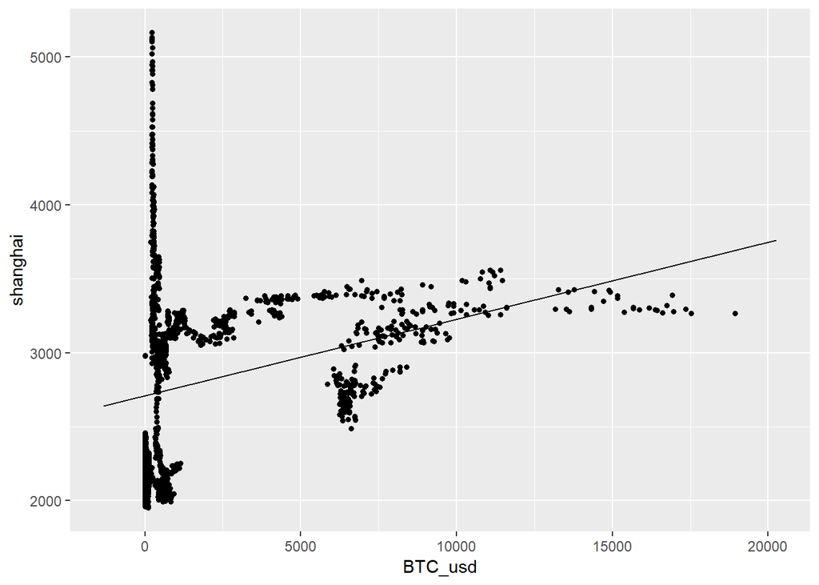

Vi ser at en lineær modell ikke passer for tidsintervallet. Kanskje prøve en ikke lineær-modell eller ikke-lineær funksjon. shanghai mot log(BTC) gir en mye bedre fit. Vi kan undersøke det lineære forholdet mellom shanghai og logaritmeverdiene av bitcoin. I enkelte ggplot-grafer er en svært lav alpha benyttet for å vise den ekstreme overplottingen for lave verdier av BTC.

```
##
## Call:
## lm(formula = shanghai ~ BTC_log, data = ukedager_log)
##
## Residuals:
##     Min      1Q  Median      3Q     Max
## -909.67 -414.82   25.53  232.42 2427.48
##
## Coefficients:
##             Estimate Std. Error t value Pr(>|t|)
## (Intercept) 2049.626     41.694   49.16   <2e-16 ***
## BTC_log      126.805      6.603   19.20   <2e-16 ***
## ---
## Signif. codes:  0 '***' 0.001 '**' 0.01 '*' 0.05 '.' 0.1 ' ' 1
##
## Residual standard error: 563.1 on 1638 degrees of freedom
## Multiple R-squared:  0.1838, Adjusted R-squared:  0.1833
## F-statistic: 368.9 on 1 and 1638 DF,  p-value: < 2.2e-16
```

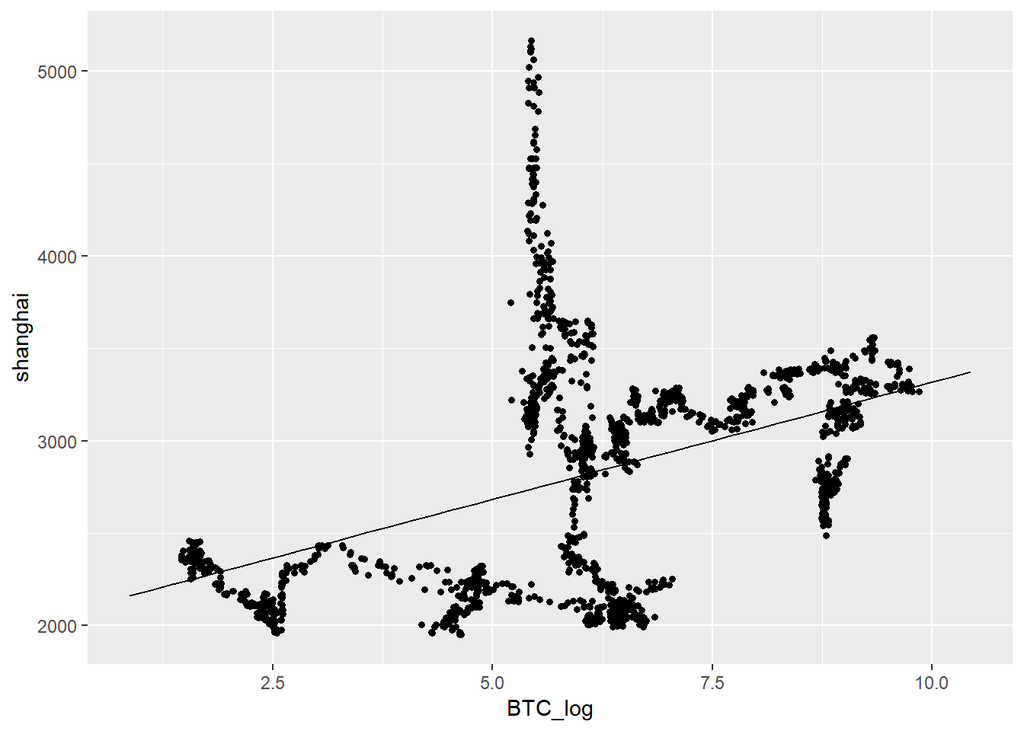

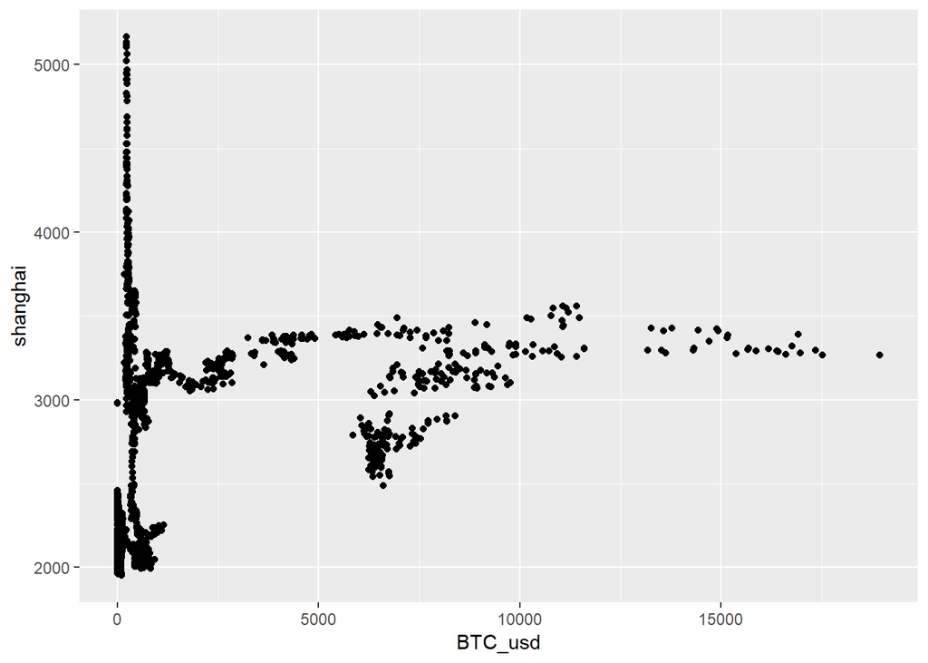

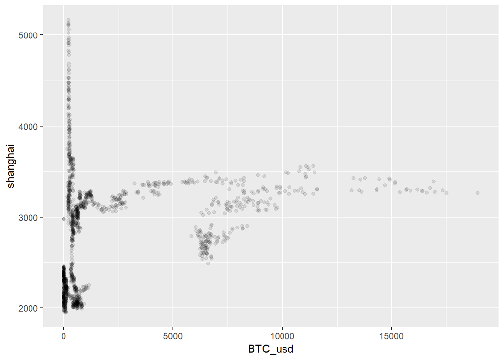

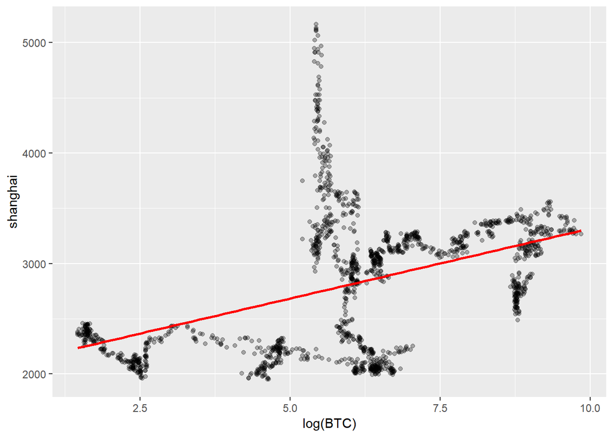

```
##
## Call:
## lm(formula = shanghai ~ log(BTC_usd), data = ukedager_log)
##
## Residuals:
##     Min      1Q  Median      3Q     Max
## -909.67 -414.82   25.53  232.42 2427.48
##
## Coefficients:
##              Estimate Std. Error t value Pr(>|t|)
## (Intercept)  2049.626     41.694   49.16   <2e-16 ***
## log(BTC_usd)  126.805      6.603   19.20   <2e-16 ***
## ---
## Signif. codes:  0 '***' 0.001 '**' 0.01 '*' 0.05 '.' 0.1 ' ' 1
##
## Residual standard error: 563.1 on 1638 degrees of freedom
## Multiple R-squared:  0.1838, Adjusted R-squared:  0.1833
## F-statistic: 368.9 on 1 and 1638 DF,  p-value: < 2.2e-16
```

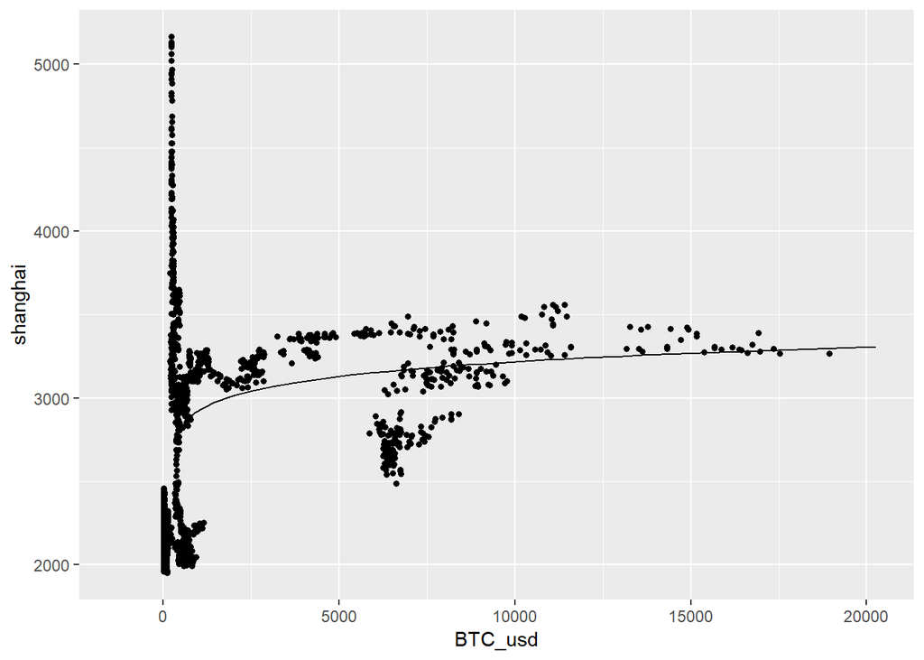

```
##
## Call:
## lm(formula = shanghai ~ BTC_usd, data = ukedager2017)
##
## Residuals:
##     Min      1Q  Median      3Q     Max
## -648.53  -62.45   58.55  154.20  406.05
##
## Coefficients:
##              Estimate Std. Error t value Pr(>|t|)
## (Intercept) 3.109e+03  2.076e+01 149.793   <2e-16 ***
## BTC_usd     3.848e-03  2.955e-03   1.303    0.193
## ---
## Signif. codes:  0 '***' 0.001 '**' 0.01 '*' 0.05 '.' 0.1 ' ' 1
##
## Residual standard error: 240.3 on 453 degrees of freedom
## Multiple R-squared:  0.003731,   Adjusted R-squared:  0.001532
## F-statistic: 1.697 on 1 and 453 DF,  p-value: 0.1934
```

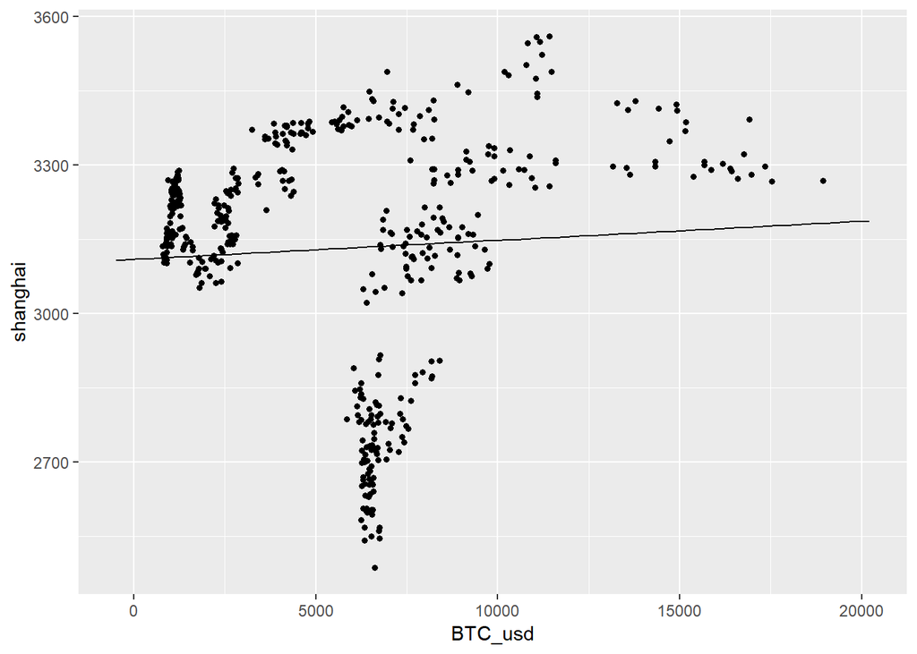

```
##
## Call:
## lm(formula = shanghai ~ BTC_usd, data = ukedager2018)
##
## Residuals:
##     Min      1Q  Median      3Q     Max
## -526.95 -141.17  -23.59  154.83  602.37
##
## Coefficients:
##              Estimate Std. Error t value Pr(>|t|)
## (Intercept) 2.164e+03  5.102e+01   42.42   <2e-16 ***
## BTC_usd     1.037e-01  6.160e-03   16.83   <2e-16 ***
## ---
## Signif. codes:  0 '***' 0.001 '**' 0.01 '*' 0.05 '.' 0.1 ' ' 1
##
## Residual standard error: 184 on 209 degrees of freedom
## Multiple R-squared:  0.5755, Adjusted R-squared:  0.5735
## F-statistic: 283.3 on 1 and 209 DF,  p-value: < 2.2e-16
```

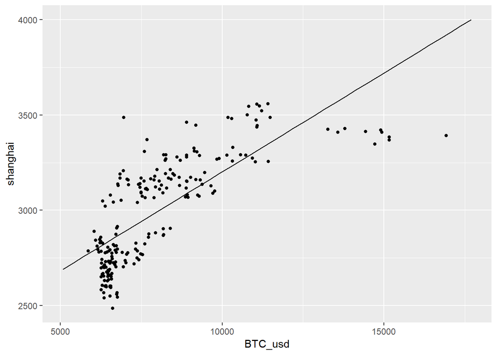

Vi er interessert i å se hvordan korrelasjonen har utviklet seg over tid. Vi har benyttet 100 dagers glidende korrelasjon. Korrelasjonen på 100 dager flyttes mot høyre. Enhver observasjonen er et resultat av de siste 100 dagene.

```r
rolling_cor <- ukedager %>%
  mutate(cor_100 = slide2(shanghai, BTC_usd, cor, .size = 100, .align = "right")) %>%
  unnest() %>%
  na.omit()

mean.cor <- cor(rolling_cor$shanghai,rolling_cor$BTC_usd)
mean.100.cor <- mean(rolling_cor$cor_100)
mean.cor
```

```
## [1] 0.3030838
```

```r
mean.100.cor
```

```
## [1] -0.007177117
```

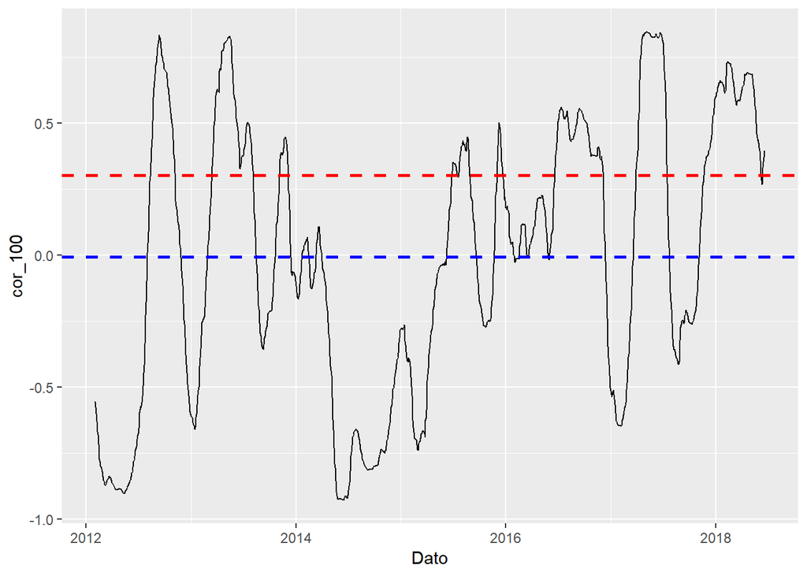

```r
ggplot(data = rolling_cor) + geom_line(aes(x = Dato, y = cor_100)) +
  geom_hline(yintercept=mean.cor, linetype="dashed", color = "red", size=1) +
  geom_hline(yintercept=mean.100.cor, linetype="dashed", color = "blue", size=1)
```

Korrelasjonen varierer sterkt. Den gjennomsnittlige korrelasjonen er høyere enn gjennomsnittet av den 100-dagers glidende korrelasjonen. Hva betyr dette?

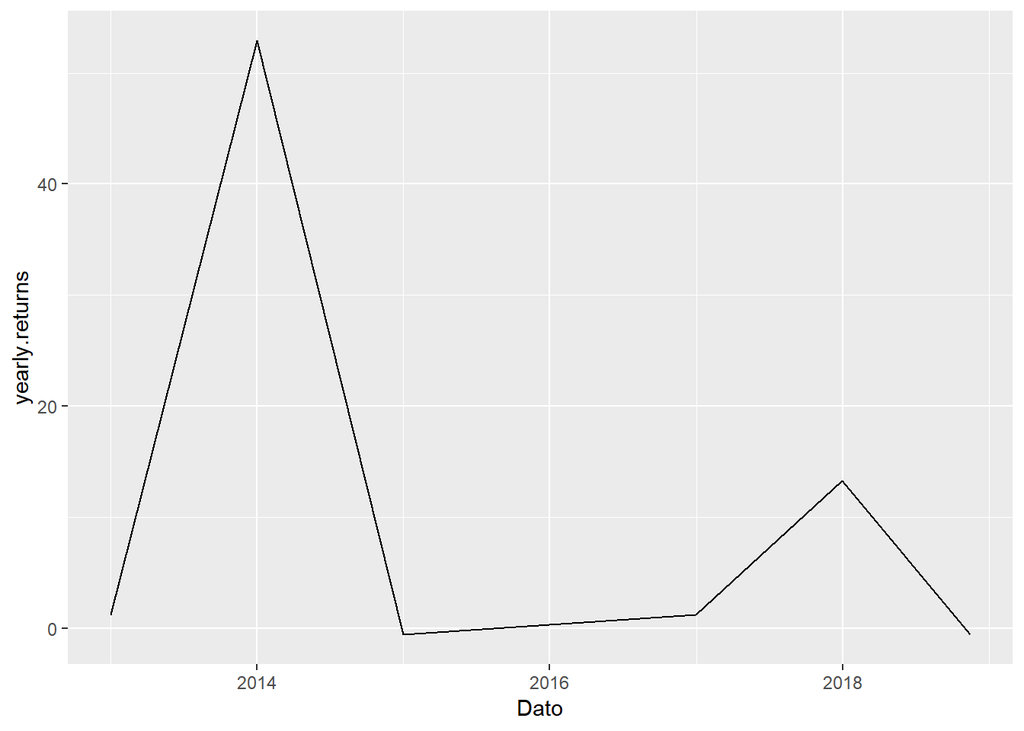

Konklusjon: Hovedindeksen og bitcoin-prisen er positivt korrelerte. Det vil si at når BTC øker, øker også shanghai. Modellen sier ikke noe om årsak og effekt.

Vi benytter samme data for BTC og samme metode for å slå sammen datasett.

```
## # A tibble: 3,180 x 4
##    Dato       BTC_usd index    verdi
##    <date>       <dbl> <chr>    <dbl>
##  1 2018-11-14   6359. shanghai 2632.
##  2 2018-11-13   6464. shanghai 2655.
##  3 2018-11-12   6447. shanghai 2631.
##  4 2018-11-09   6420. shanghai 2599.
##  5 2018-11-08   6480. shanghai 2636.
##  6 2018-11-07   6573. shanghai 2641.
##  7 2018-11-06   6515. shanghai 2659.
##  8 2018-11-05   6470. shanghai 2665.
##  9 2018-11-02   6427. shanghai 2676.
## 10 2018-11-01   6400. shanghai 2606.
## # ... with 3,170 more rows
```

```
##
## Call:
## lm(formula = sp500 ~ BTC_usd, data = ukedager)
##
## Residuals:
##     Min      1Q  Median      3Q     Max
## -1059.6  -186.3    80.6   216.7   423.7
##
## Coefficients:
##              Estimate Std. Error t value Pr(>|t|)
## (Intercept) 1.857e+03  8.210e+00  226.23   <2e-16 ***
## BTC_usd     9.995e-02  2.207e-03   45.28   <2e-16 ***
## ---
## Signif. codes:  0 '***' 0.001 '**' 0.01 '*' 0.05 '.' 0.1 ' ' 1
##
## Residual standard error: 283 on 1588 degrees of freedom
## Multiple R-squared:  0.5635, Adjusted R-squared:  0.5632
## F-statistic:  2050 on 1 and 1588 DF,  p-value: < 2.2e-16
```

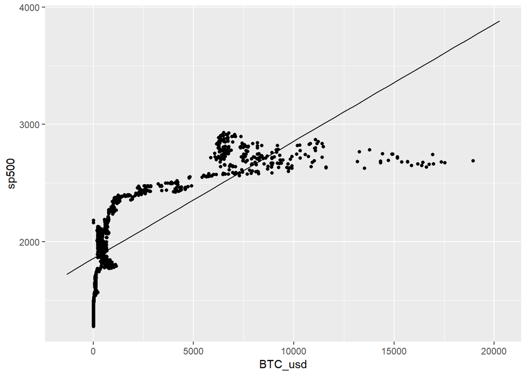

```
##
## Call:
## lm(formula = sp500 ~ BTC_log, data = ukedager_log)
##
## Residuals:
##     Min      1Q  Median      3Q     Max
## -458.80  -82.06   25.51   91.56  345.30
##
## Coefficients:
##             Estimate Std. Error t value Pr(>|t|)
## (Intercept)  897.544     10.691   83.95   <2e-16 ***
## BTC_log      192.252      1.691  113.71   <2e-16 ***
## ---
## Signif. codes:  0 '***' 0.001 '**' 0.01 '*' 0.05 '.' 0.1 ' ' 1
##
## Residual standard error: 141.7 on 1585 degrees of freedom
## Multiple R-squared:  0.8908, Adjusted R-squared:  0.8907
## F-statistic: 1.293e+04 on 1 and 1585 DF,  p-value: < 2.2e-16
```

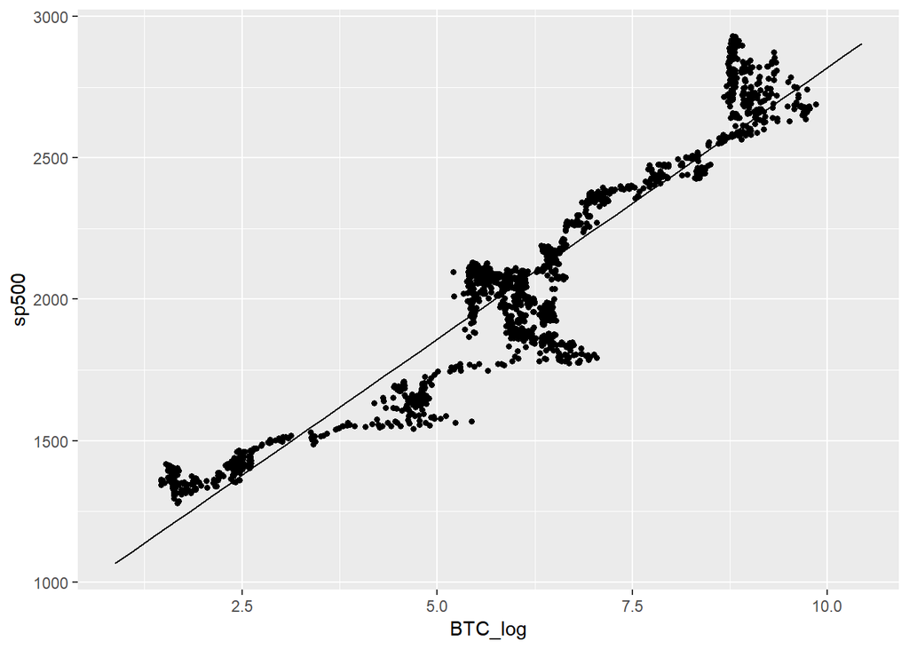

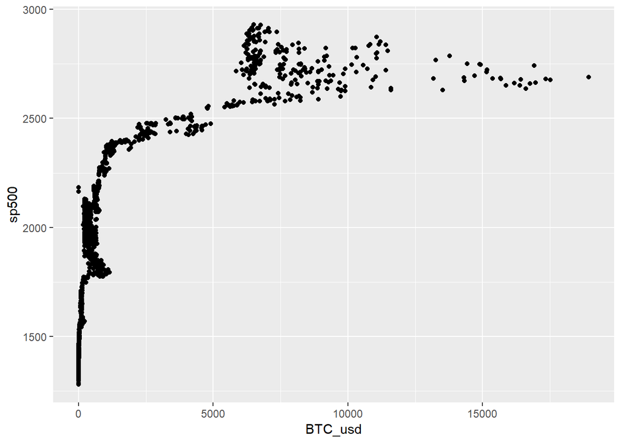

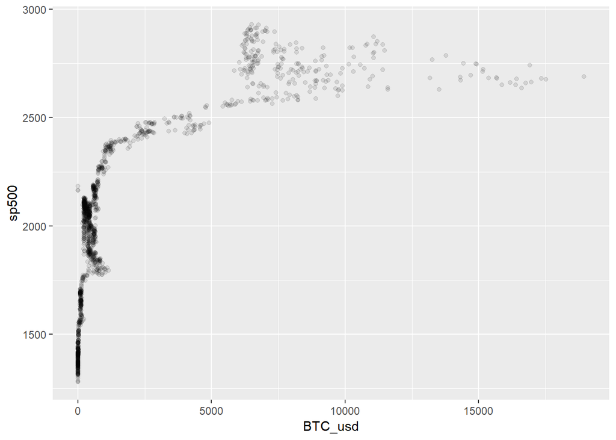

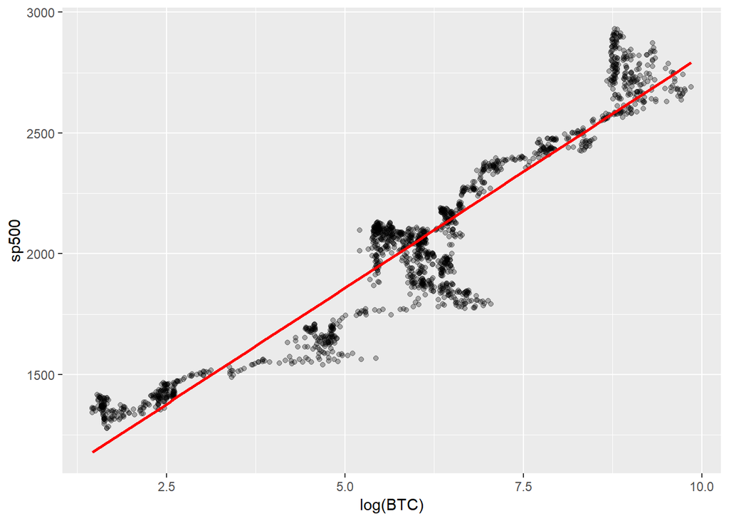

```
##
## Call:
## lm(formula = sp500 ~ log(BTC_usd), data = ukedager_log)
##
## Residuals:
##     Min      1Q  Median      3Q     Max
## -458.80  -82.06   25.51   91.56  345.30
##
## Coefficients:
##              Estimate Std. Error t value Pr(>|t|)
## (Intercept)   897.544     10.691   83.95   <2e-16 ***
## log(BTC_usd)  192.252      1.691  113.71   <2e-16 ***
## ---
## Signif. codes:  0 '***' 0.001 '**' 0.01 '*' 0.05 '.' 0.1 ' ' 1
##
## Residual standard error: 141.7 on 1585 degrees of freedom
## Multiple R-squared:  0.8908, Adjusted R-squared:  0.8907
## F-statistic: 1.293e+04 on 1 and 1585 DF,  p-value: < 2.2e-16
```

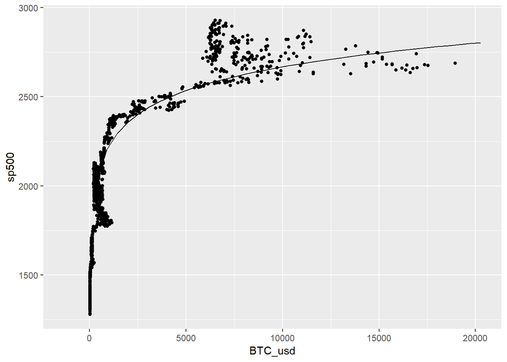

```
##
## Call:
## lm(formula = sp500 ~ BTC_usd, data = ukedager2017)
##
## Residuals:
##     Min      1Q  Median      3Q     Max
## -353.84  -75.94  -33.22   76.79  313.58
##
## Coefficients:
##              Estimate Std. Error t value Pr(>|t|)
## (Intercept) 2.394e+03  1.126e+01   212.7   <2e-16 ***
## BTC_usd     3.433e-02  1.604e-03    21.4   <2e-16 ***
## ---
## Signif. codes:  0 '***' 0.001 '**' 0.01 '*' 0.05 '.' 0.1 ' ' 1
##
## Residual standard error: 128.4 on 441 degrees of freedom
## Multiple R-squared:  0.5094, Adjusted R-squared:  0.5083
## F-statistic: 457.9 on 1 and 441 DF,  p-value: < 2.2e-16
```

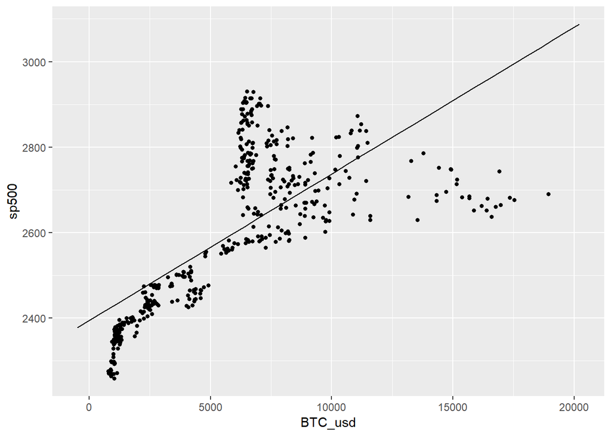

```
##
## Call:
## lm(formula = sp500 ~ BTC_usd, data = ukedager2018)
##
## Residuals:
##      Min       1Q   Median       3Q      Max
## -188.662  -54.187   -5.433   62.019  156.798
##
## Coefficients:
##               Estimate Std. Error t value Pr(>|t|)
## (Intercept)  2.827e+03  2.267e+01 124.690  < 2e-16 ***
## BTC_usd     -8.033e-03  2.741e-03  -2.931  0.00377 **
## ---
## Signif. codes:  0 '***' 0.001 '**' 0.01 '*' 0.05 '.' 0.1 ' ' 1
##
## Residual standard error: 80.22 on 204 degrees of freedom
## Multiple R-squared:  0.0404, Adjusted R-squared:  0.0357
## F-statistic: 8.589 on 1 and 204 DF,  p-value: 0.003768
```

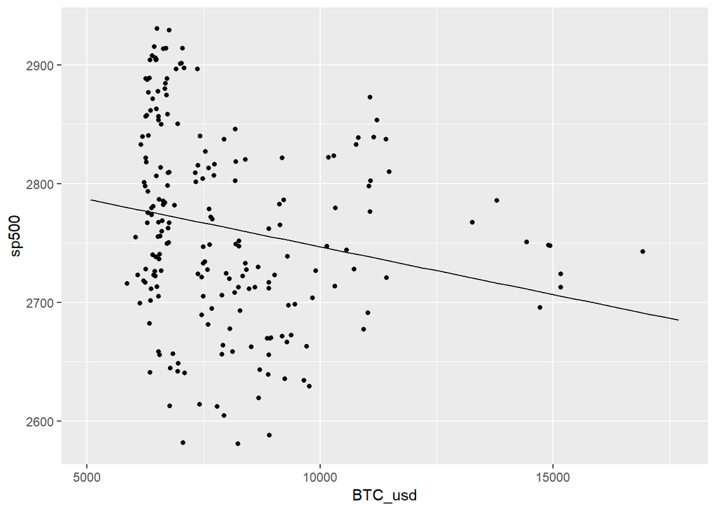

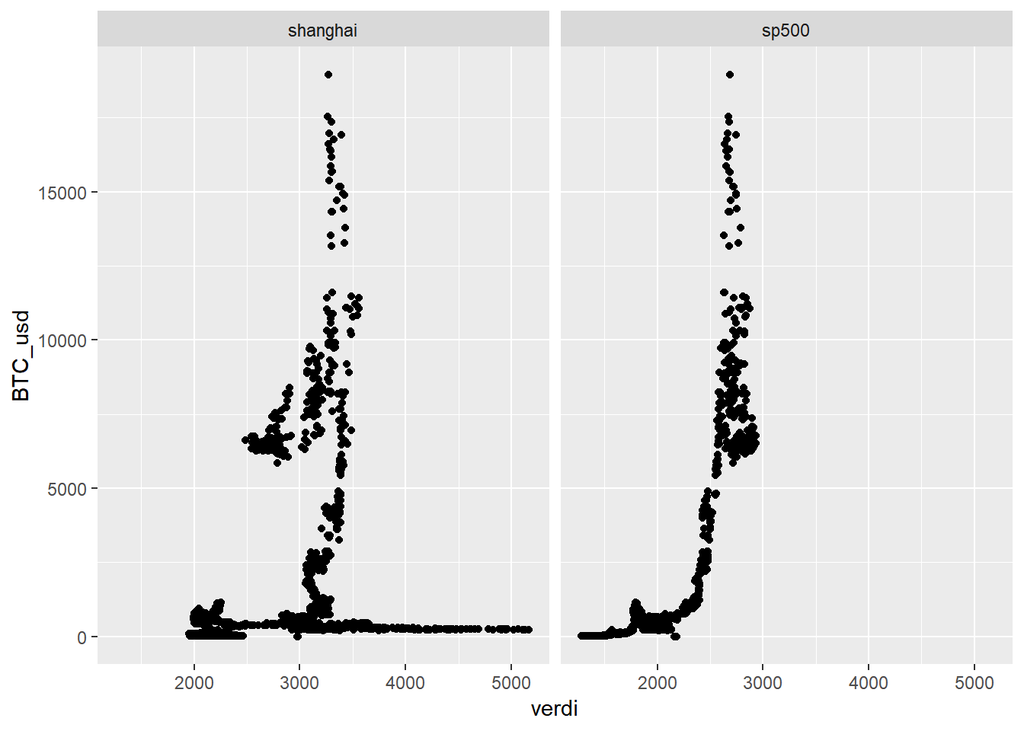

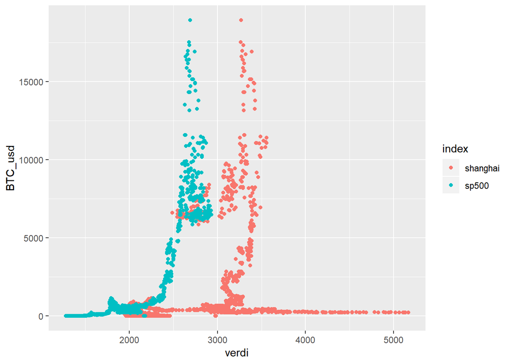

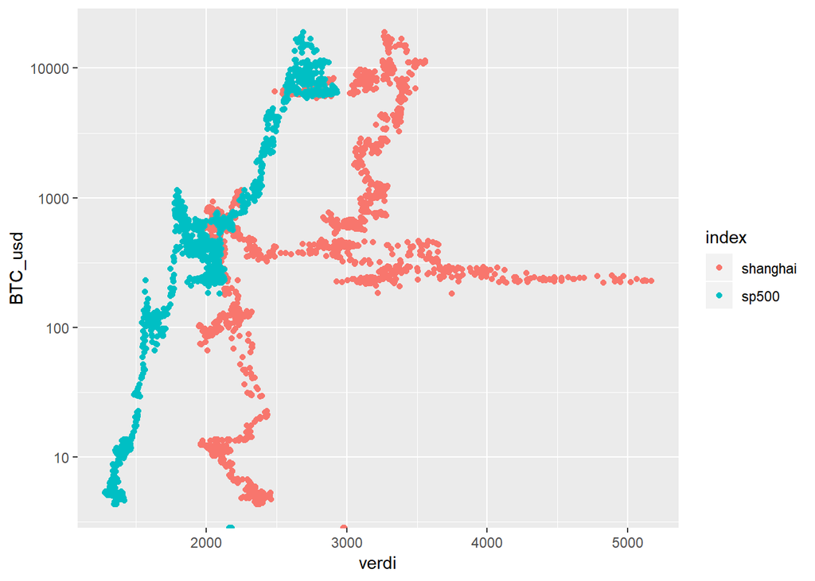

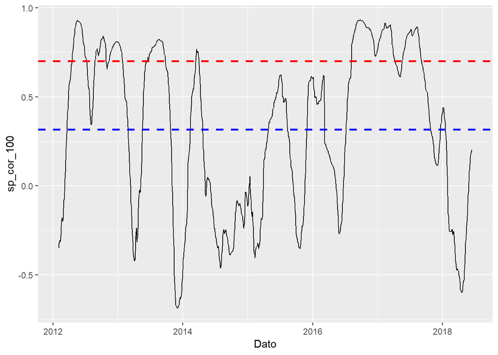